# External validation of the CFS tool in a hospitalised elderly population

This is an external validation of the Clinical Frailty Score (CFS) in a hospitalised and potentially frail elderly population. The purpose of an external validation is to determine whether a tool is useful in a different population to the one it was developed for. In this case, our research question was whether the CFS was useful in a hospitalised elderly population for predicting 90-day mortality. Given that the population is substantially older, we were also interested in whether adding age as a predictor was able to improve the model’s predictions. The research plan has been approved using dummy data and will measure the following components:

- Model discrimination, or whether the model assigned higher risks to patients who died
- Model calibration, or whether the model accurately predicts the expected number of deaths
- Model fit with and without age as a predictor
- The net benefit of using the models
- The stability of predictions from the models

```r
library(ggthemes)
library(extrafont)
library(remotes)
library(rms)
library(CalibrationCurves)
library(dcurves)
library(survival)
library(survminer)
library(flextable)
library(patchwork)
library(viridis)
library(tidyverse)

options(scipen = 100, digits = 5)
loadfonts(quiet = T)
```

# Data preparation

## Sample size calculations

A preliminary sample size calculation is required to determine whether we have sufficient data to evaluate the model. A simple implementation has been published by Riley and colleagues: https://doi.org/10.1002/sim.9025 through the `pmsampsize` package.

```r
pmsampsize::pmsampsize(
  type = "b",
  parameters = 5,
  prevalence = 0.2,
  cstatistic = 0.6
)
```

```
## Given input C-statistic = 0.6  & prevalence = 0.2
## Cox-Snell R-sq = 0.0197
##
## NB: Assuming 0.05 acceptable difference in apparent & adjusted R-squared
## NB: Assuming 0.05 margin of error in estimation of intercept
## NB: Events per Predictor Parameter (EPP) assumes prevalence = 0.2
##
##            Samp_size Shrinkage Parameter CS_Rsq Max_Rsq Nag_Rsq   EPP
## Criteria 1      2260     0.900         5 0.0197   0.632   0.031 90.40
## Criteria 2       155     0.384         5 0.0197   0.632   0.031  6.20
## Criteria 3       246     0.900         5 0.0197   0.632   0.031  9.84
## Final           2260     0.900         5 0.0197   0.632   0.031 90.40
##
##  Minimum sample size required for new model development based on user inputs = 2260,
##  with 452 events (assuming an outcome prevalence = 0.2) and an EPP = 90.4
##
##
```

The package suggests a sample size of at least 2260 observations with 452 deaths. A quick survey of our data shows that we are OK.

## Preliminary analysis of mortality in our population

We can take a quick look at the survival rate of patients given their CFS scores to determine how unwell our population is and, at a glance, how well the CFS can stratify them.

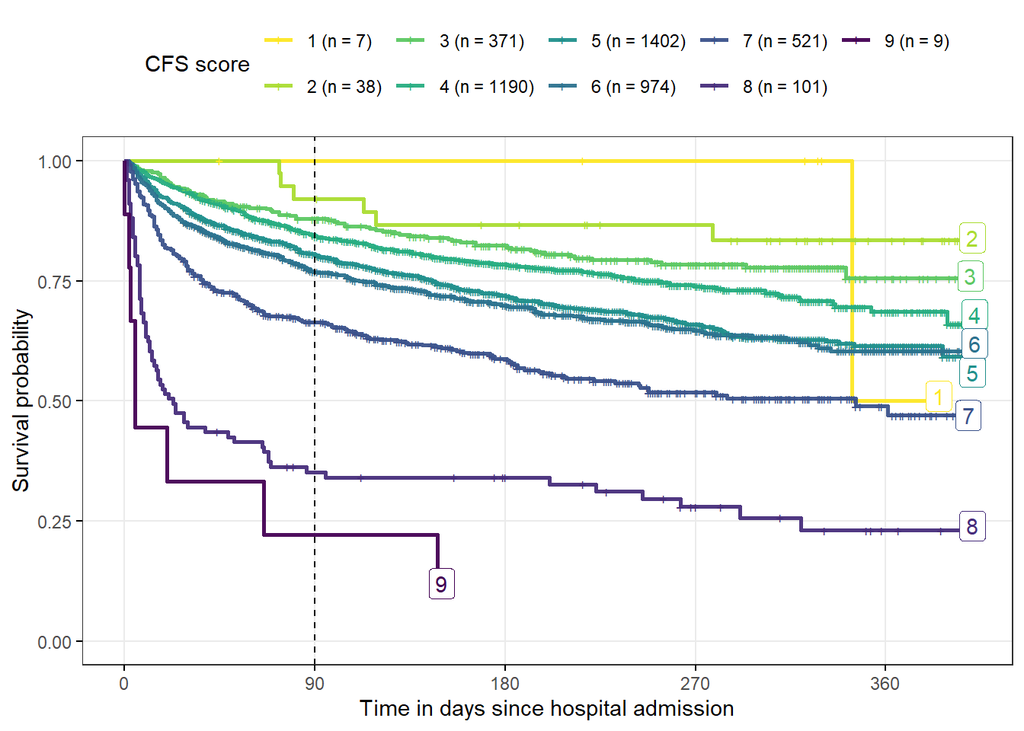

## Missing data

We also have a handful of missing values in our dataset for the CFS score. We are, at least, confident that our age and outcome variables are reliable.

```r
paste0(sum(is.na(df_pred$cristal_cfs_score)), " missing CFS values")
```

```
## [1] "26 missing CFS values"
```

These will have to be imputed. Because so few data points are missing (<1% of the data) and we are not aware of any factors that could influence missingness, we should be OK with single imputation.

```r
imp <- aregImpute(
  ~ spict_score + cristal_cfs_score + cristal_score_1 + cristal_score_2 + cristal_score +
    age_on_admission + death_90d,
  data = df_pred,
  n.impute = 1
)
```

```
## Iteration 1
```

```r
df_pred$cristal_cfs_score[is.na(df_pred$cristal_cfs_score)] <- imp$imputed$cristal_cfs_score
remove(imp)
paste0(sum(is.na(df_pred$cristal_cfs_score)), " missing CFS values")
```

```
## [1] "0 missing CFS values"
```

## Turning CFS values into predicted probabilities

CFS scores may correspond to something in clinical care, but we need to turn them into probabilities to make them evaluable by other metrics like calibration. The easiest way to do this is to fit a simple logistic regression model with 90-day mortality as our outcome and CFS as our sole predictor.

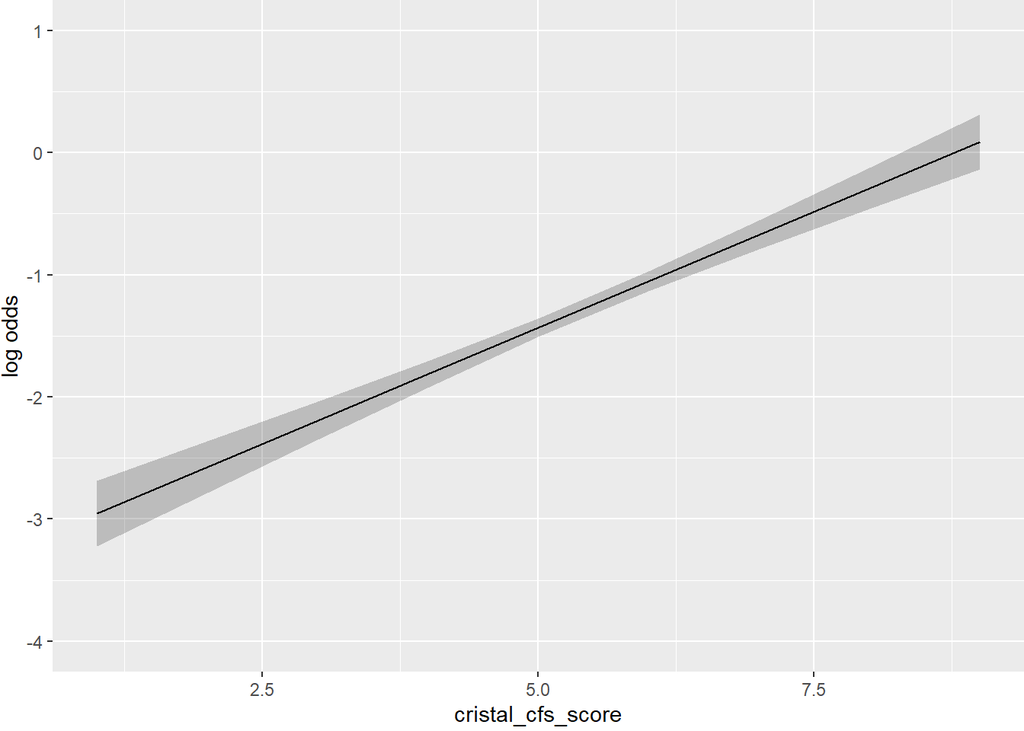

```r
dd <- datadist(df_pred)
options(datadist = dd)
fit <- lrm(death_90d ~ cristal_cfs_score, data = df_pred)
df_pred$pred <- predict(fit, type = "fitted")
ggplot(Predict(fit))
```

# Model evaluation

Now that our data are prepared for analysis, we can assess the CFS properly. This can be done first using discrimination, or the ability of the model to assign higher risk scores to patients who died, and calibration, or the ability of the model to assign risks that are proportional to the observed rate of death in our population.

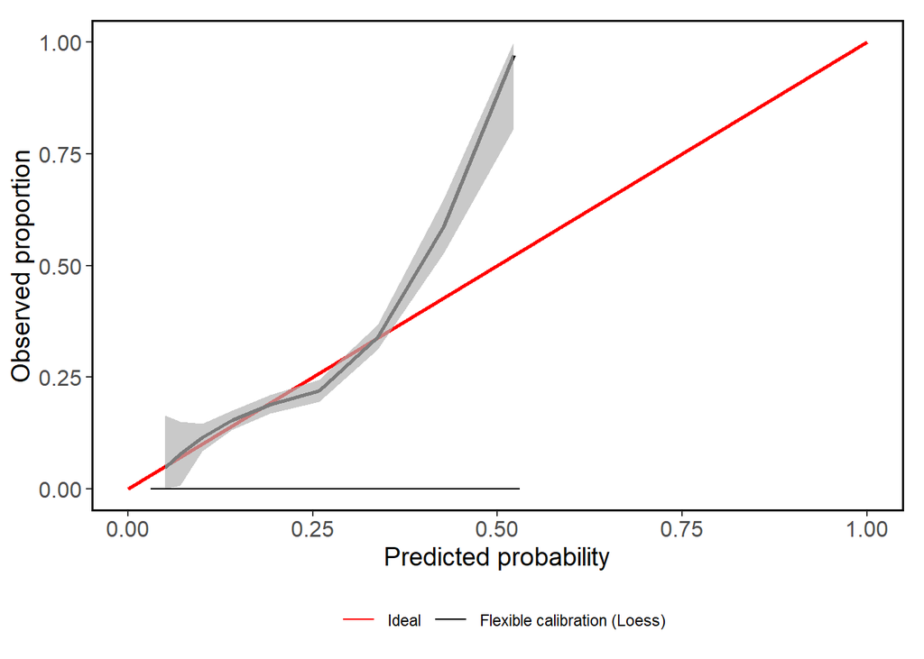

```
## Call:
## valProbggplot(p = df_pred$pred, y = df_pred$death_90d, logit = "p",
##     xlim = c(0, 1), ylim = c(0, 1), statloc = c(0.65, 0.2), dostats = FALSE,
##     d0lab = NULL, d1lab = NULL, line.bins = 0, length.seg = 0)
##
## A 95% confidence interval is given for the calibration intercept, calibration slope and c-statistic.
##
##                     Dxy                 C (ROC)                      R2
##   0.2382577078673130122   0.6191288539336564645   0.0556326455553852184
##                       D                D:Chi-sq                     D:p
##   0.0359507958496081831 167.7757419463323458331   0.0000000000000000000
##                       U                U:Chi-sq                     U:p
##  -0.0004311273981412508   0.0000000000227373675   0.9999999999886313162
##                       Q                   Brier               Intercept
##   0.0363819232477494356   0.1569517956688460114  -0.0000000000001209649
##                   Slope                    Emax            Brier scaled
##   0.9999999999999951150   0.0000000000000019984   0.0406978392410294321
##                    Eavg                     ECI
##   0.0185154602963816042   0.1334861308394230395
```

This plot shows us that the discrimination of the model is around 0.62 [0.60, 0.64], which is not particularly good, given that the c-statistic ranges from 0.5 (no better than random chance) to 1 (perfectly separates patients who died and survived). The calibration of the model is also OK for the majority of CFS scores up to around 7, but CFS scores of 8 and 9 tend to dramatically underestimate risk (the observed mortality rate for these patients rises much faster than the predicted probabilities).

# Modifying the CFS: Does the addition of age improve model performance?

We can test whether age improves the model by repeating the above process. The best way to check whether the new model does a better job of explaining our data is through the likelihood ratio Chi-squared test. First though, we should assess whether the effect of age on our predictions is roughly linear.

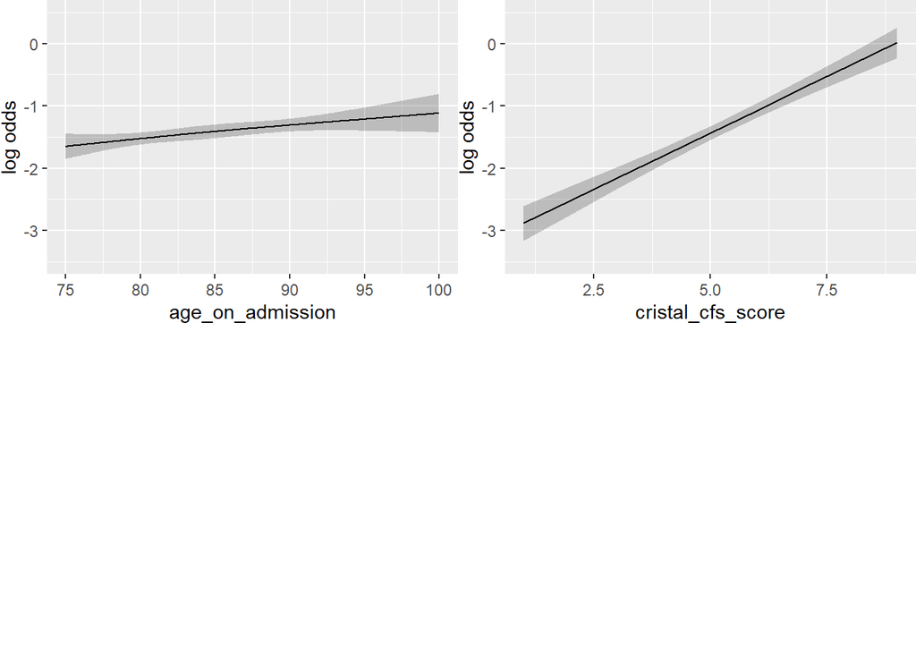

```
##                 Wald Statistics          Response: death_90d
##
##  Factor            Chi-Square d.f. P
##  cristal_cfs_score 141.23     1    <.0001
##  age_on_admission   11.69     2    0.0029
##   Nonlinear          0.04     1    0.8388
##  TOTAL             171.12     3    <.0001
```

Adding a non-linear transformation of age to the model appears to be unwarranted, which means that the effect of age is roughly linear in our population. We can just use an untransformed variable to fit our model. Now we can run the LR test.

```
##
## Model 1: death_90d ~ cristal_cfs_score
## Model 2: death_90d ~ cristal_cfs_score + age_on_admission
##
##  L.R. Chisq        d.f.           P
## 11.66943468  1.00000000  0.00063535
```

This result suggests that we may get better predictions from the new model compared to the old model. However, we still need to test that idea.

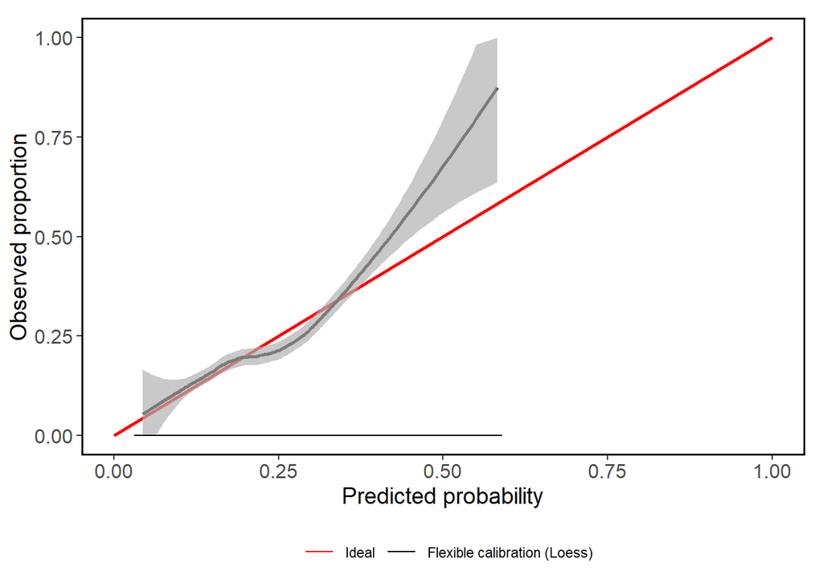

```
## Call:
## valProbggplot(p = df_pred$pred2, y = df_pred$death_90d, logit = "p",
##     xlim = c(0, 1), ylim = c(0, 1), statloc = c(0.65, 0.2), dostats = FALSE,
##     d0lab = NULL, d1lab = NULL, line.bins = 0, length.seg = 0)
##
## A 95% confidence interval is given for the calibration intercept, calibration slope and c-statistic.
##
##                     Dxy                 C (ROC)                      R2
##   0.2586130212658636074   0.6293065106329318592   0.0594277798394593285
##                       D                D:Chi-sq                     D:p
##   0.0384663023548492064 179.4451766241454606643   0.0000000000000000000
##                       U                U:Chi-sq                     U:p
##  -0.0004311273981377219   0.0000000000391082722   0.9999999999804458639
##                       Q                   Brier               Intercept
##   0.0388974297529869270   0.1566053858320632930  -0.0000000000002662905
##                   Slope                    Emax            Brier scaled
##   1.0000000000000055511   0.0000000000000025535   0.0428151243827361583
##                    Eavg                     ECI
##   0.0186140631882925379   0.0688002486090316112
```

This appears to be marginally better. The c-statistic isn’t much higher (0.63 [0.61, 0.65]), and the risk underestimation has been slightly toned down for higher CFS scores.

We can also see a much more widely distributed set of risks in the histograms of the two models predictions.

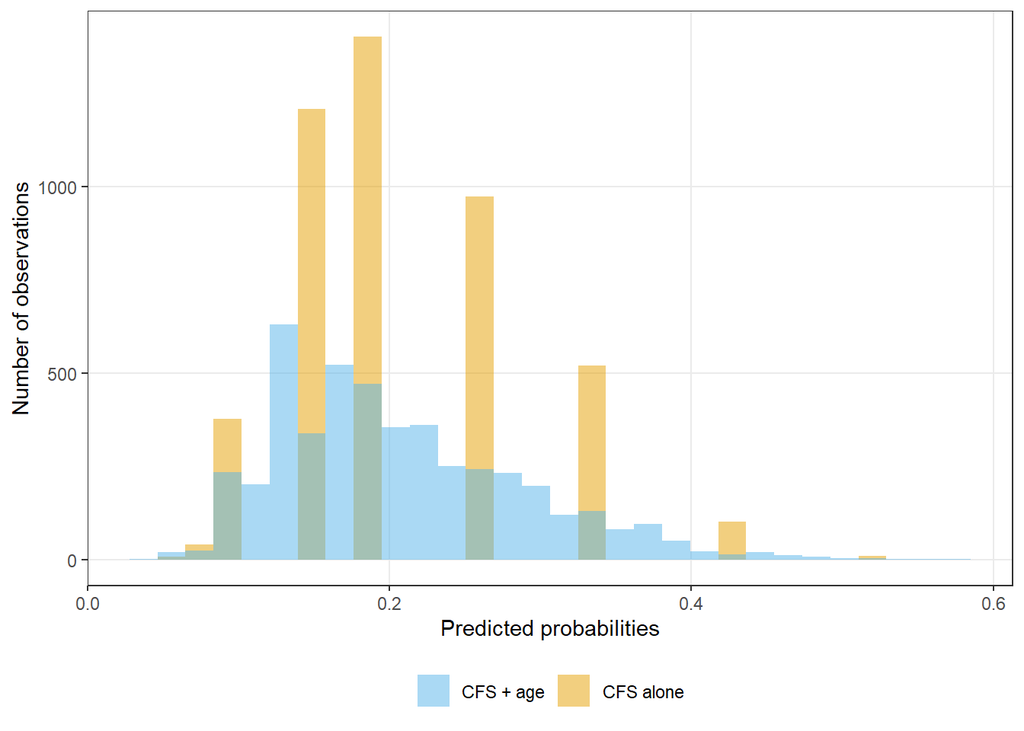

Assessing the value of the models using net benefit is a good way to determine the appropriate thresholds one might use for decision-making. In the case of the CFS, we may use it in this population to decide who to review for palliative care, or discussion of advanced directives.

```
## Assuming '1' is [Event] and '0' is [non-Event]
```

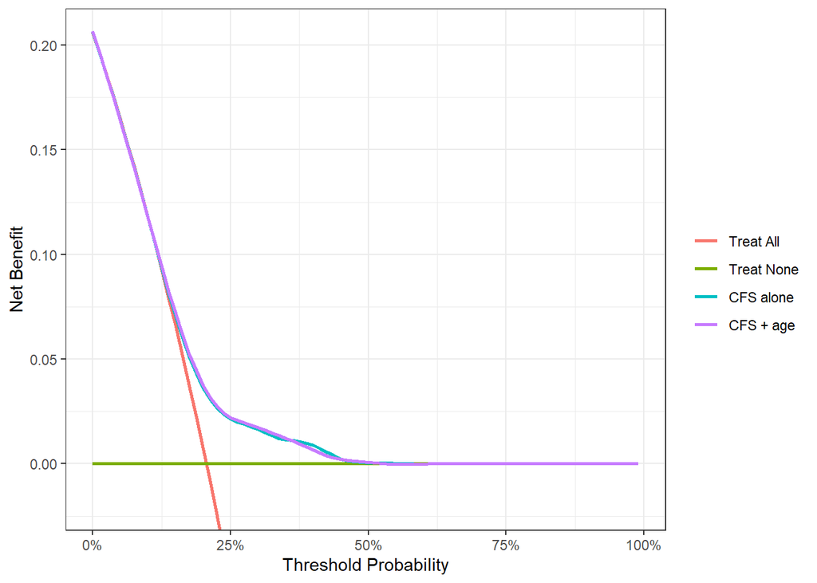

There appears to be a marginal benefit of using the CFS, but not much changes by adding age. The net benefit plot shows that the gains identified by using the CFS in our population occur predominantly around the lower to middle set of predicted probabilities. These correspond to CFS scores of around 5 to 7.

# Post-hoc analysis

We observed non-linearity in the relationship between CFS score and 90-day mortality. As a post-hoc analysis, we investigated whether it may be more appropriate to fit a non-linear term for CFS in the model.

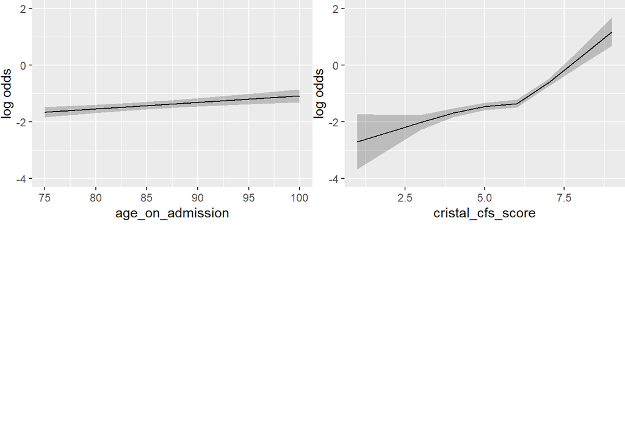

```r
fit3 <- lrm(death_90d ~ rcs(cristal_cfs_score, 5) + age_on_admission, data = df_pred)
ggplot(Predict(fit3))
```

```r
anova(fit3)
```

```
##                 Wald Statistics          Response: death_90d
##
##  Factor            Chi-Square d.f. P
##  cristal_cfs_score 173.57     4    <.0001
##   Nonlinear         28.66     3    <.0001
##  age_on_admission   12.90     1    0.0003
##  TOTAL             203.26     5    <.0001
```

```r
lrtest(fit3, fit2)
```

```
##
## Model 1: death_90d ~ rcs(cristal_cfs_score, 5) + age_on_admission
## Model 2: death_90d ~ cristal_cfs_score + age_on_admission
##
##   L.R. Chisq         d.f.            P
## 29.872467469  3.000000000  0.000001468
```

The Wald test demonstrates a strongly non-linear relationship. Running model discrimination and calibration statistics again could show an interesting result:

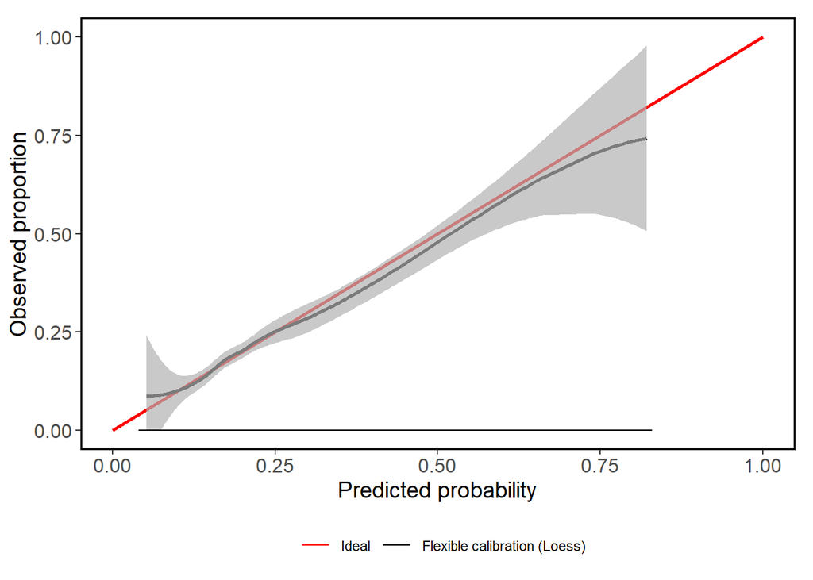

```
## Call:
## valProbggplot(p = df_pred$pred3, y = df_pred$death_90d, logit = "p",
##     xlim = c(0, 1), ylim = c(0, 1), statloc = c(0.65, 0.2), dostats = FALSE,
##     d0lab = NULL, d1lab = NULL, line.bins = 0, length.seg = 0)
##
## A 95% confidence interval is given for the calibration intercept, calibration slope and c-statistic.
##
##                    Dxy                C (ROC)                     R2
##   0.262592631302705992   0.631296315651353024   0.069099517880705841
##                      D               D:Chi-sq                    D:p
##   0.044905721942869958 209.317644092973750958   0.000000000000000000
##                      U               U:Chi-sq                    U:p
##  -0.000431127398154190  -0.000000000037289283   1.000000000000000000
##                      Q                  Brier              Intercept
##   0.045336849341024152   0.155200107057372000   0.000000000000026055
##                  Slope                   Emax           Brier scaled
##   0.999999999999829026   0.000000000000057621   0.051404302730681972
##                   Eavg                    ECI
##   0.006955815703220846   0.009599717643182784
```

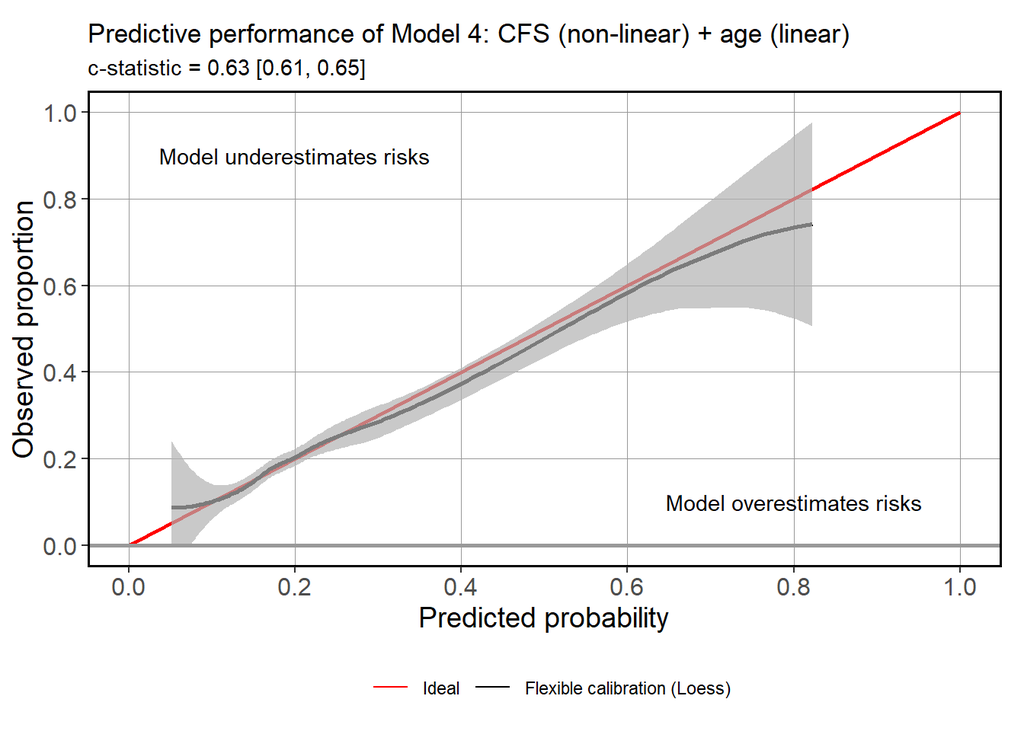

Combining all three model performance plots to make them publication ready:

[figure not shown]

```r
(p2$ggPlot +
  ggtitle("Model 1: CFS alone (linear)",
          subtitle = "c-statistic = 0.62 [0.60, 0.64]") +
  geom_hline(yintercept = 0, colour = "#999999", linewidth = 1) +
  theme(legend.position = "none") +
  theme(panel.grid.major = element_line(colour = "#999999", linewidth = 0.2)) +
  scale_x_continuous(breaks = seq(0, 1, 0.2)) +
  scale_y_continuous(breaks = seq(0, 1, 0.2)) +
  annotate(geom = "text",
           label = "Model underestimates risks",
           x = 0.22, y = 0.9) +
  annotate(geom = "text",
           label = "Model overestimates risks",
           x = 0.8, y = 0.1)) /
  (p3$ggPlot +
  ggtitle("Model 2: CFS (linear) + age (linear)",
          subtitle = "c-statistic = 0.63 [0.61, 0.65]") +
  geom_hline(yintercept = 0, colour = "#999999", linewidth = 1) +
  scale_x_continuous(breaks = seq(0, 1, 0.2)) +
  scale_y_continuous(breaks = seq(0, 1, 0.2)) +
  theme(panel.grid.major = element_line(colour = "#999999", linewidth = 0.2)) +
  theme(legend.position = "none") +
  annotate(geom = "text",
           label = "Model underestimates risks",
           x = 0.22, y = 0.9) +
  annotate(geom = "text",
           label = "Model overestimates risks",
           x = 0.8, y = 0.1)) /
  p5$ggPlot +
  ggtitle("Model 4: CFS (non-linear) + age (linear)",
          subtitle = "c-statistic = 0.63 [0.61, 0.65]") +
  geom_hline(yintercept = 0, colour = "#999999", linewidth = 1) +
  theme(panel.grid.major = element_line(colour = "#999999", linewidth = 0.2)) +
  scale_x_continuous(breaks = seq(0, 1, 0.2)) +
  scale_y_continuous(breaks = seq(0, 1, 0.2)) +
  theme(legend.position = "bottom") +
  annotate(geom = "text",
           label = "Model underestimates risks",
           x = 0.22, y = 0.9) +
  annotate(geom = "text",
           label = "Model overestimates risks",
           x = 0.8, y = 0.1)
```

```r
ggsave("./Figure2.png", height = 10, width = 5)
```

While the c-statistic appears unchanged, the calibration is now significantly improved. Demonstration of the form of the coefficients appears to confirm the non-linearity of the CFS in terms of its relationship with 90-day mortality.

This suggests that the CFS in its unmodified form may suffer from poor calibration, but this issue can be improved by transforming the CFS score and adjusting for patient age. We can repeat the histogram to check the predictions for this new model.

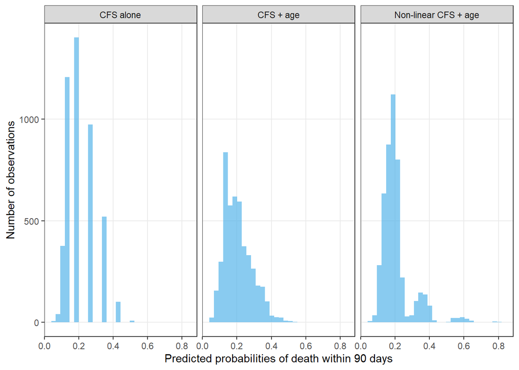

We can also, finally, just check whether the net benefit is improved with this model.

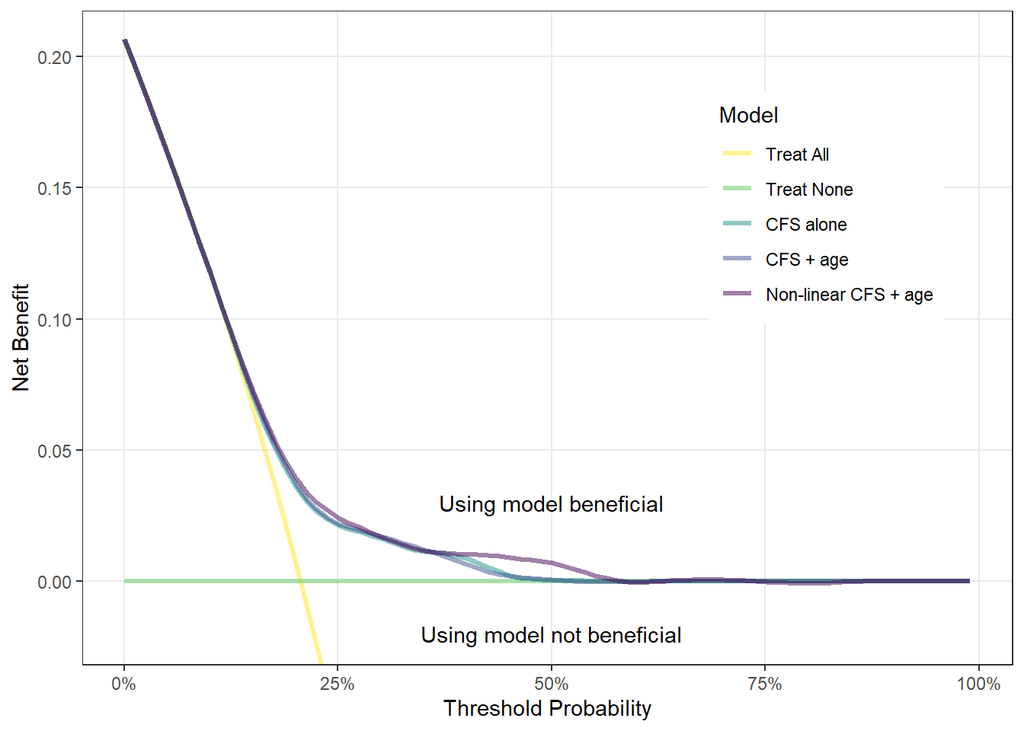

Net benefit appears to be marginally better.

# Checking the stability of models developed in our population

When developing or externally validating clinical prediction models, it often pays to make sure that the predicted risks are not unduly influenced by random variation in the sample population. This can be done through checking model instability, or the degree to which the predicted risks change. As we have many patients, a high number of events, and an extremely parsimonious model (one or two predictors at most), this is unlikely to be a problem, but we’ll check anyway.

The best way to do this is actually just to repeat the entire model fitting process.

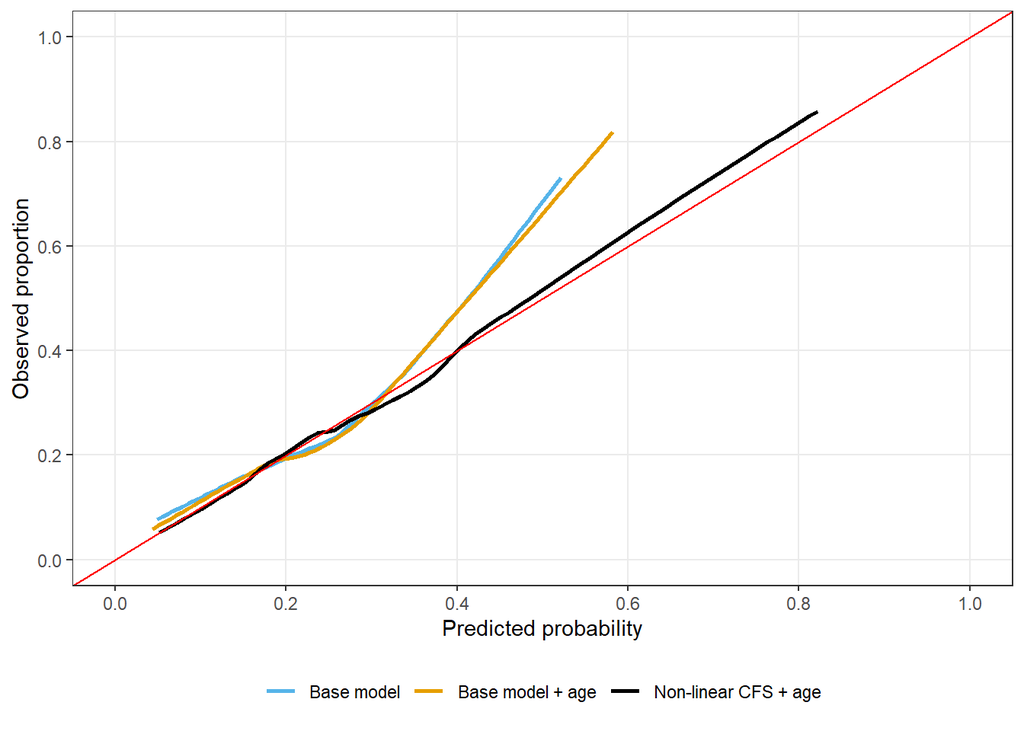

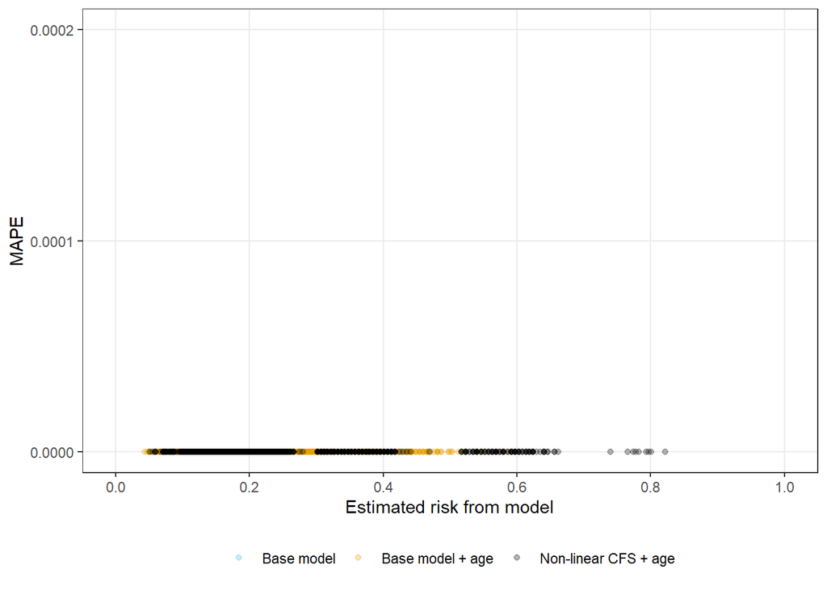

Neither plot shows anything to be worried about - the mean prediction error and mean calibration error are not detectable on our graphs. The total prediction error is also virtually 0, meaning model stability isn’t really an issue here.

```
## [1] "MAPE, base model: 0.00000000000000000329500661444649"
```

```
## [1] "MAPE, base model + age: 0.00000000000000000519294760093465"
```

```
## [1] "MAPE, non-linear CFS + age: 0.0000000000000000225143437311864"
```